#### - Nombre: Manuel Matías Corredoira de Soto

#### - Asignatura : Machine Learning

#### - Entrega: Análisis Exploratorio de Datos

# Análisis Exploratorio de datos

## Tabla de contenidos

### 1º) Datos generales

### 2º) Análisis explicativo

### 3º) Análisis exploratorio

### 4º) Conclusiones

### 5º) Referencias

## Datos generales

#### Para este caso se ha decidido trbajar con la base de datos de la Liga, la cual contiene una lista de diferentes estadísticas de los jugadores que pertenecen a la misma.

### Carga de librerías necesarias

```python
import pandas as pd

import numpy as np

import matplotlib.pyplot  as plt

import seaborn as sns

%matplotlib inline
```

### Carga de la base da datos

```python
LaLiga= pd.read_csv('../data/laliga_player_stats_english.csv',delimiter=',')
LaLiga
```

|  | Team | Position | Shirt number | Name | Minutes played | Games played | Percentage of games played | Full games played | Percentage of full games played | Games started | ... | Corners | Tackles.1 | Duels | Man-to-man duels | Aerial duels | Passes | Short passes | Long passes | Through balls | Goals scored per attempt |
| --- | --- | --- | --- | --- | --- | --- | --- | --- | --- | --- | --- | --- | --- | --- | --- | --- | --- | --- | --- | --- | --- |
| 0 | Athletic Club | Goalkeeper | NaN | Hodei Oleaga | 0.000 | 0 | 0,0% | 0 | 0,0% | 0 | ... | 0 | 0 | 0 | 0 | 0 | 0.0 | 0.0 | 0 | 0 | 0 |
| 1 | Athletic Club | Goalkeeper | 1.0 | A. Remiro | 0.000 | 0 | 0,0% | 0 | 0,0% | 0 | ... | 0 | 0 | 0 | 0 | 0 | 0.0 | 0.0 | 0 | 0 | 0 |
| 2 | Athletic Club | Goalkeeper | 13.0 | Herrerín | 2.790 | 31 | 82,0% | 31 | 82,0% | 31 | ... | 0 | 0 | 25 | 6 | 19 | 887.0 | 128.0 | 759 | 1 | 0 |
| 3 | Athletic Club | Goalkeeper | 25.0 | Unai Simón | 630.000 | 7 | 18,0% | 7 | 18,0% | 7 | ... | 0 | 0 | 3 | 2 | 1 | 155.0 | 49.0 | 106 | 0 | 0 |
| 4 | Athletic Club | Defender | 3.0 | Núñez | 1.063 | 12 | 32,0% | 11 | 29,0% | 11 | ... | 0 | 15 | 107 | 38 | 69 | 536.0 | 457.0 | 78 | 1 | 0 |
| ... | ... | ... | ... | ... | ... | ... | ... | ... | ... | ... | ... | ... | ... | ... | ... | ... | ... | ... | ... | ... | ... |
| 551 | Villarreal CF | Midfielder | 37.0 | Iván Martín | 0.000 | 0 | 0,0% | 0 | 0,0% | 0 | ... | 0 | 0 | 0 | 0 | 0 | 0.0 | 0.0 | 0 | 0 | 0 |
| 552 | Villarreal CF | Midfielder | 42.0 | Andrei Ratiu | 0.000 | 0 | 0,0% | 0 | 0,0% | 0 | ... | 0 | 0 | 0 | 0 | 0 | 0.0 | 0.0 | 0 | 0 | 0 |
| 553 | Villarreal CF | Forward | 7.0 | Gerard | 2.317 | 35 | 92,0% | 16 | 42,0% | 25 | ... | 0 | 23 | 344 | 219 | 125 | 740.0 | 676.0 | 59 | 5 | 6 |
| 554 | Villarreal CF | Forward | 9.0 | Bacca | 1.259 | 33 | 87,0% | 2 | 5,0% | 12 | ... | 1 | 4 | 127 | 80 | 47 | 270.0 | 252.0 | 16 | 2 | 5 |
| 555 | Villarreal CF | Forward | 17.0 | Toko Ekambi | 2.148 | 34 | 89,0% | 11 | 29,0% | 24 | ... | 0 | 11 | 268 | 187 | 81 | 501.0 | 477.0 | 23 | 1 | 5 |

556 rows × 62 columns

## Análisis Explicativo

### Número de observaciones y variables

```python
LaLiga.shape
```

```
(556, 62)
```

### Número de observaciones en la base de datos

```python
len(LaLiga)
```

```
556
```

### Caracteríticas de la base de datos, principalmente sus variables

```python
LaLiga.info()
```

```
<class 'pandas.core.frame.DataFrame'>
RangeIndex: 556 entries, 0 to 555
Data columns (total 62 columns):
 #   Column                                 Non-Null Count  Dtype
---  ------                                 --------------  -----
 0   Team                                   556 non-null    object
 1   Position                               556 non-null    object
 2   Shirt number                           526 non-null    float64
 3   Name                                   556 non-null    object
 4   Minutes played                         556 non-null    float64
 5   Games played                           556 non-null    int64
 6   Percentage of games played             556 non-null    object
 7   Full games played                      556 non-null    int64
 8   Percentage of full games played        556 non-null    object
 9   Games started                          556 non-null    int64
```

[output cut: 54 more lines]

#### Se ve que la mayoría de variables son de tipo int64, sin embargo tambien las hay tanto tipo float64 como object. Además de las 556 observaciones y 62 variables

### Búsqueda de valores nulos

```python
LaLiga.isnull().any()
```

```
Team                        False
Position                    False
Shirt number                 True
Name                        False
Minutes played              False
                            ...
Passes                      False
Short passes                False
Long passes                 False
Through balls               False
Goals scored per attempt    False
Length: 62, dtype: bool
```

#### Solamente hay en la variables Shirt number, las cuales pertenecen a jugadores que no llegan a participar en partidos

### Cuenta de valores totales nulos

```python
LaLiga.isnull().sum()
```

```
Team                         0
Position                     0
Shirt number                30
Name                         0
Minutes played               0
                            ..
Passes                       0
Short passes                 0
Long passes                  0
Through balls                0
Goals scored per attempt     0
Length: 62, dtype: int64
```

#### Hay un total de 30 nulos en Shirt number

### Resumen General de algunos de los principales estadísticos

```python
LaLiga.describe()
```

|  | Shirt number | Minutes played | Games played | Full games played | Games started | Games where substituted | Yellow Cards | Red Cards | Second Yellows | Goals scored | ... | Corners | Tackles.1 | Duels | Man-to-man duels | Aerial duels | Passes | Short passes | Long passes | Through balls | Goals scored per attempt |
| --- | --- | --- | --- | --- | --- | --- | --- | --- | --- | --- | --- | --- | --- | --- | --- | --- | --- | --- | --- | --- | --- |
| count | 526.000000 | 556.000000 | 556.000000 | 556.000000 | 556.000000 | 556.000000 | 556.000000 | 556.000000 | 556.000000 | 556.000000 | ... | 556.000000 | 556.000000 | 556.000000 | 556.000000 | 556.000000 | 556.000000 | 556.000000 | 556.000000 | 556.000000 | 556.000000 |
| mean | 15.688213 | 125.863646 | 18.602518 | 10.798561 | 14.825540 | 7.803957 | 3.284173 | 0.138489 | 0.084532 | 1.696043 | ... | 6.485612 | 22.598921 | 151.870504 | 102.411871 | 49.458633 | 298.276849 | 287.366338 | 86.906475 | 1.705036 | 1.059353 |
| std | 10.143810 | 239.665055 | 12.462351 | 10.560289 | 11.746272 | 7.635341 | 3.320995 | 0.398954 | 0.309102 | 3.503828 | ... | 19.998328 | 22.882684 | 137.610291 | 97.469928 | 58.638456 | 323.996696 | 303.818053 | 126.842323 | 4.109673 | 1.746575 |
| min | 1.000000 | 0.000000 | 0.000000 | 0.000000 | 0.000000 | 0.000000 | 0.000000 | 0.000000 | 0.000000 | 0.000000 | ... | 0.000000 | 0.000000 | 0.000000 | 0.000000 | 0.000000 | 0.000000 | 0.000000 | 0.000000 | 0.000000 | 0.000000 |
| 25% | 7.250000 | 1.546250 | 6.000000 | 1.000000 | 3.750000 | 1.000000 | 0.000000 | 0.000000 | 0.000000 | 0.000000 | ... | 0.000000 | 2.000000 | 20.000000 | 12.000000 | 6.750000 | 1.436000 | 1.701750 | 7.000000 | 0.000000 | 0.000000 |
| 50% | 15.000000 | 2.413000 | 20.000000 | 8.000000 | 14.500000 | 5.000000 | 2.000000 | 0.000000 | 0.000000 | 0.000000 | ... | 0.000000 | 16.000000 | 127.000000 | 79.000000 | 32.000000 | 165.000000 | 166.000000 | 43.500000 | 0.000000 | 0.000000 |
| 75% | 22.000000 | 90.000000 | 31.000000 | 18.250000 | 25.000000 | 13.000000 | 5.000000 | 0.000000 | 0.000000 | 2.000000 | ... | 1.000000 | 38.000000 | 247.000000 | 170.000000 | 73.250000 | 579.250000 | 549.500000 | 113.500000 | 2.000000 | 1.000000 |
| max | 57.000000 | 999.000000 | 38.000000 | 38.000000 | 38.000000 | 34.000000 | 15.000000 | 2.000000 | 2.000000 | 36.000000 | ... | 170.000000 | 110.000000 | 746.000000 | 452.000000 | 442.000000 | 987.000000 | 987.000000 | 988.000000 | 70.000000 | 10.000000 |

8 rows × 55 columns

#### Principalmente llamativo a grosso modo son las 15 tarjetas amarillas recibidas de máximo, teniendo en cuenta que la liga son solo 38 jornadas, lo cual supone una tarjeta cada 2.53 partidos.

### Primeras observaciones de la base

```python
LaLiga.head()
```

|  | Team | Position | Shirt number | Name | Minutes played | Games played | Percentage of games played | Full games played | Percentage of full games played | Games started | ... | Corners | Tackles.1 | Duels | Man-to-man duels | Aerial duels | Passes | Short passes | Long passes | Through balls | Goals scored per attempt |
| --- | --- | --- | --- | --- | --- | --- | --- | --- | --- | --- | --- | --- | --- | --- | --- | --- | --- | --- | --- | --- | --- |
| 0 | Athletic Club | Goalkeeper | NaN | Hodei Oleaga | 0.000 | 0 | 0,0% | 0 | 0,0% | 0 | ... | 0 | 0 | 0 | 0 | 0 | 0.0 | 0.0 | 0 | 0 | 0 |
| 1 | Athletic Club | Goalkeeper | 1.0 | A. Remiro | 0.000 | 0 | 0,0% | 0 | 0,0% | 0 | ... | 0 | 0 | 0 | 0 | 0 | 0.0 | 0.0 | 0 | 0 | 0 |
| 2 | Athletic Club | Goalkeeper | 13.0 | Herrerín | 2.790 | 31 | 82,0% | 31 | 82,0% | 31 | ... | 0 | 0 | 25 | 6 | 19 | 887.0 | 128.0 | 759 | 1 | 0 |
| 3 | Athletic Club | Goalkeeper | 25.0 | Unai Simón | 630.000 | 7 | 18,0% | 7 | 18,0% | 7 | ... | 0 | 0 | 3 | 2 | 1 | 155.0 | 49.0 | 106 | 0 | 0 |
| 4 | Athletic Club | Defender | 3.0 | Núñez | 1.063 | 12 | 32,0% | 11 | 29,0% | 11 | ... | 0 | 15 | 107 | 38 | 69 | 536.0 | 457.0 | 78 | 1 | 0 |

5 rows × 62 columns

### Últimas observaciones

```python
LaLiga.tail()
```

|  | Team | Position | Shirt number | Name | Minutes played | Games played | Percentage of games played | Full games played | Percentage of full games played | Games started | ... | Corners | Tackles.1 | Duels | Man-to-man duels | Aerial duels | Passes | Short passes | Long passes | Through balls | Goals scored per attempt |
| --- | --- | --- | --- | --- | --- | --- | --- | --- | --- | --- | --- | --- | --- | --- | --- | --- | --- | --- | --- | --- | --- |
| 551 | Villarreal CF | Midfielder | 37.0 | Iván Martín | 0.000 | 0 | 0,0% | 0 | 0,0% | 0 | ... | 0 | 0 | 0 | 0 | 0 | 0.0 | 0.0 | 0 | 0 | 0 |
| 552 | Villarreal CF | Midfielder | 42.0 | Andrei Ratiu | 0.000 | 0 | 0,0% | 0 | 0,0% | 0 | ... | 0 | 0 | 0 | 0 | 0 | 0.0 | 0.0 | 0 | 0 | 0 |
| 553 | Villarreal CF | Forward | 7.0 | Gerard | 2.317 | 35 | 92,0% | 16 | 42,0% | 25 | ... | 0 | 23 | 344 | 219 | 125 | 740.0 | 676.0 | 59 | 5 | 6 |
| 554 | Villarreal CF | Forward | 9.0 | Bacca | 1.259 | 33 | 87,0% | 2 | 5,0% | 12 | ... | 1 | 4 | 127 | 80 | 47 | 270.0 | 252.0 | 16 | 2 | 5 |
| 555 | Villarreal CF | Forward | 17.0 | Toko Ekambi | 2.148 | 34 | 89,0% | 11 | 29,0% | 24 | ... | 0 | 11 | 268 | 187 | 81 | 501.0 | 477.0 | 23 | 1 | 5 |

5 rows × 62 columns

### Lista de equipos de la competición

```python
team=list(LaLiga["Team"].unique())
team
```

```
['Athletic Club',
 'Atlético de Madrid',
 'CD Leganés',
 'D. Alavés',
 'FC Barcelona',
 'Getafe CF',
 'Girona FC',
 'Levante UD',
 'R. Valladolid CF',
 'Rayo Vallecano',
 'RC Celta',
 'RCD Espanyol',
 'Real Betis',
 'Real Madrid',
 'Real Sociedad',
 'SD Eibar',
 'SD Huesca',
 'Sevilla FC',
 'Valencia CF',
 'Villarreal CF']
```

## Análisis exploratorio

### Correlaciones entre variables

```python
LaLiga.corr()
```

|  | Shirt number | Minutes played | Games played | Full games played | Games started | Games where substituted | Yellow Cards | Red Cards | Second Yellows | Goals scored | ... | Corners | Tackles.1 | Duels | Man-to-man duels | Aerial duels | Passes | Short passes | Long passes | Through balls | Goals scored per attempt |
| --- | --- | --- | --- | --- | --- | --- | --- | --- | --- | --- | --- | --- | --- | --- | --- | --- | --- | --- | --- | --- | --- |
| Shirt number | 1.000000 | -0.023747 | -0.445639 | -0.407365 | -0.436118 | -0.149732 | -0.306484 | -0.132050 | -0.137574 | -0.156100 | ... | -0.065372 | -0.268964 | -0.299594 | -0.250522 | -0.283212 | -0.234597 | -0.212086 | -0.312927 | -0.116210 | -0.192949 |
| Minutes played | -0.023747 | 1.000000 | -0.282421 | -0.369789 | -0.376947 | 0.050482 | -0.287554 | -0.102330 | -0.094863 | -0.172889 | ... | -0.119874 | -0.291537 | -0.304444 | -0.284668 | -0.241275 | -0.125847 | -0.163448 | -0.241243 | -0.139585 | -0.191986 |
| Games played | -0.445639 | -0.282421 | 1.000000 | 0.792256 | 0.933683 | 0.536439 | 0.661288 | 0.210047 | 0.172447 | 0.459130 | ... | 0.313202 | 0.686068 | 0.820527 | 0.784455 | 0.621643 | 0.425143 | 0.484956 | 0.507765 | 0.374453 | 0.542212 |
| Full games played | -0.407365 | -0.369789 | 0.792256 | 1.000000 | 0.927010 | -0.089965 | 0.630635 | 0.192242 | 0.159783 | 0.272985 | ... | 0.194911 | 0.645322 | 0.613937 | 0.547254 | 0.531106 | 0.250479 | 0.287420 | 0.736982 | 0.218003 | 0.302996 |
| Games started | -0.436118 | -0.376947 | 0.933683 | 0.927010 | 1.000000 | 0.241822 | 0.688889 | 0.229322 | 0.189669 | 0.411500 | ... | 0.295546 | 0.714953 | 0.788916 | 0.739689 | 0.621871 | 0.365791 | 0.419378 | 0.631917 | 0.332505 | 0.468351 |
| Games where substituted | -0.149732 | 0.050482 | 0.536439 | -0.089965 | 0.241822 | 1.000000 | 0.207131 | 0.076951 | 0.060475 | 0.371829 | ... | 0.241629 | 0.227263 | 0.490135 | 0.523487 | 0.280079 | 0.347483 | 0.394017 | -0.190535 | 0.309663 | 0.465927 |
| Yellow Cards | -0.306484 | -0.287554 | 0.661288 | 0.630635 | 0.688889 | 0.207131 | 1.000000 | 0.223189 | 0.180165 | 0.225767 | ... | 0.219948 | 0.745997 | 0.709986 | 0.658618 | 0.571399 | 0.237499 | 0.386207 | 0.319517 | 0.186752 | 0.285046 |
| Red Cards | -0.132050 | -0.102330 | 0.210047 | 0.192242 | 0.229322 | 0.076951 | 0.223189 | 1.000000 | 0.796172 | 0.040480 | ... | 0.078276 | 0.247476 | 0.227045 | 0.203611 | 0.194373 | 0.140150 | 0.196471 | 0.114836 | 0.108479 | 0.104544 |
| Second Yellows | -0.137574 | -0.094863 | 0.172447 | 0.159783 | 0.189669 | 0.060475 | 0.180165 | 0.796172 | 1.000000 | 0.040403 | ... | 0.064760 | 0.204773 | 0.192868 | 0.163484 | 0.180868 | 0.139473 | 0.165888 | 0.103511 | 0.074981 | 0.087477 |
| Goals scored | -0.156100 | -0.172889 | 0.459130 | 0.272985 | 0.411500 | 0.371829 | 0.225767 | 0.040480 | 0.040403 | 1.000000 | ... | 0.225463 | 0.126437 | 0.543434 | 0.502761 | 0.439609 | 0.203766 | 0.229592 | -0.048811 | 0.615902 | 0.915087 |
| Penalties scored | -0.116790 | -0.079644 | 0.270085 | 0.186059 | 0.258392 | 0.183496 | 0.145178 | 0.069573 | 0.040330 | 0.727209 | ... | 0.230800 | 0.056137 | 0.344413 | 0.305100 | 0.301111 | 0.108251 | 0.099227 | -0.015402 | 0.381850 | 0.664371 |
| Own goals | -0.136648 | -0.029685 | 0.124266 | 0.193037 | 0.159702 | -0.064160 | 0.161223 | 0.043790 | 0.016860 | 0.015296 | ... | -0.054992 | 0.127790 | 0.124283 | 0.057553 | 0.195996 | 0.083766 | 0.178992 | 0.114845 | -0.031530 | 0.029872 |
| Goals conceded while player on pitch | -0.422842 | -0.325553 | 0.882537 | 0.867473 | 0.921999 | 0.240685 | 0.650378 | 0.217309 | 0.191625 | 0.361822 | ... | 0.265192 | 0.661637 | 0.734059 | 0.694982 | 0.567448 | 0.349843 | 0.407614 | 0.579880 | 0.255326 | 0.424871 |
| Tackles | -0.270487 | -0.190257 | 0.416374 | 0.572827 | 0.506116 | -0.112663 | 0.521691 | 0.235683 | 0.194613 | -0.017255 | ... | -0.025658 | 0.530444 | 0.375523 | 0.242094 | 0.478848 | 0.067170 | 0.214417 | 0.314631 | -0.020504 | 0.059492 |
| Interceptions | -0.306093 | -0.292703 | 0.625868 | 0.692117 | 0.689869 | 0.064284 | 0.715375 | 0.271672 | 0.230919 | 0.019450 | ... | 0.180603 | 0.833686 | 0.615620 | 0.564079 | 0.507087 | 0.142561 | 0.312344 | 0.359649 | 0.109834 | 0.103855 |
| Recoveries | -0.382502 | -0.338221 | 0.803917 | 0.879624 | 0.883910 | 0.095557 | 0.596179 | 0.187002 | 0.137142 | 0.119975 | ... | 0.314470 | 0.661255 | 0.575053 | 0.583835 | 0.379049 | 0.275751 | 0.276929 | 0.792074 | 0.202880 | 0.190661 |
| Clearances | -0.317115 | -0.230616 | 0.467996 | 0.668490 | 0.579445 | -0.160715 | 0.552367 | 0.289464 | 0.250250 | -0.002231 | ... | -0.071423 | 0.534537 | 0.396176 | 0.230608 | 0.546409 | 0.138762 | 0.283472 | 0.444291 | -0.049062 | 0.067323 |
| Successful tackles | -0.265185 | -0.287406 | 0.672315 | 0.643392 | 0.703626 | 0.207484 | 0.736326 | 0.257453 | 0.219799 | 0.116210 | ... | 0.277746 | 0.984311 | 0.755750 | 0.767398 | 0.497980 | 0.183396 | 0.366570 | 0.277477 | 0.199748 | 0.205492 |
| Unssuccessful tackles | -0.256306 | -0.277509 | 0.660806 | 0.605102 | 0.684097 | 0.241658 | 0.712642 | 0.214842 | 0.167764 | 0.131539 | ... | 0.322161 | 0.960080 | 0.749205 | 0.765796 | 0.485282 | 0.159257 | 0.321100 | 0.263382 | 0.217721 | 0.211109 |
| Last man | -0.159873 | -0.035144 | 0.159768 | 0.255186 | 0.216641 | -0.092170 | 0.188466 | 0.178780 | 0.126885 | -0.067123 | ... | -0.056505 | 0.202779 | 0.089966 | 0.043660 | 0.138554 | 0.058217 | 0.094302 | 0.267652 | -0.025763 | -0.048942 |
| Successful duels | -0.259057 | -0.292527 | 0.771574 | 0.586739 | 0.749385 | 0.447852 | 0.677736 | 0.217624 | 0.169759 | 0.418882 | ... | 0.422336 | 0.850225 | 0.900492 | 0.975564 | 0.491637 | 0.246223 | 0.389994 | 0.179562 | 0.493390 | 0.467663 |
| Duels lost | -0.230291 | -0.263877 | 0.760517 | 0.483741 | 0.696022 | 0.572258 | 0.609610 | 0.180635 | 0.149843 | 0.560456 | ... | 0.443253 | 0.690208 | 0.918990 | 0.977226 | 0.532283 | 0.299262 | 0.434307 | 0.066353 | 0.510768 | 0.604992 |
| Successful aerial challenges | -0.295454 | -0.235233 | 0.572399 | 0.555054 | 0.600153 | 0.166583 | 0.579640 | 0.221959 | 0.208766 | 0.342113 | ... | -0.050112 | 0.514983 | 0.726659 | 0.445205 | 0.965265 | 0.227563 | 0.351783 | 0.222484 | 0.085682 | 0.396311 |
| Unsuccessful aerial challenges | -0.247932 | -0.229319 | 0.626599 | 0.465231 | 0.597578 | 0.379280 | 0.519134 | 0.150277 | 0.137468 | 0.509669 | ... | 0.040787 | 0.457858 | 0.812518 | 0.569148 | 0.960736 | 0.274548 | 0.391962 | 0.067090 | 0.190938 | 0.571315 |
| Offsides | -0.130619 | -0.123754 | 0.425255 | 0.183439 | 0.338400 | 0.440386 | 0.166400 | 0.018325 | 0.016449 | 0.738741 | ... | 0.098418 | 0.060027 | 0.499250 | 0.411614 | 0.487428 | 0.228719 | 0.246523 | -0.117764 | 0.292247 | 0.716671 |
| Fouls suffered | -0.247117 | -0.269754 | 0.706365 | 0.501874 | 0.674943 | 0.458793 | 0.588143 | 0.203186 | 0.138837 | 0.505511 | ... | 0.356035 | 0.648692 | 0.856301 | 0.891615 | 0.527471 | 0.239432 | 0.347031 | 0.121513 | 0.494150 | 0.539835 |
| Fouls committed | -0.277902 | -0.264496 | 0.726121 | 0.549172 | 0.699092 | 0.425621 | 0.774902 | 0.250014 | 0.217650 | 0.434256 | ... | 0.237687 | 0.748049 | 0.901319 | 0.828089 | 0.738712 | 0.292463 | 0.448215 | 0.131102 | 0.277525 | 0.504784 |
| Penalties won | -0.073325 | -0.075735 | 0.273085 | 0.139931 | 0.224927 | 0.252193 | 0.137630 | 0.016896 | 0.046955 | 0.339027 | ... | 0.056838 | 0.096850 | 0.334883 | 0.324713 | 0.246146 | 0.159784 | 0.177815 | -0.061750 | 0.158389 | 0.341997 |
| Penalties given away | -0.191351 | -0.085762 | 0.223364 | 0.327163 | 0.290292 | -0.087920 | 0.350819 | 0.177183 | 0.120056 | -0.069482 | ... | 0.008087 | 0.311144 | 0.187992 | 0.133684 | 0.218959 | 0.092513 | 0.125209 | 0.239821 | -0.058555 | -0.029981 |
| Handballs committed | -0.178870 | -0.140169 | 0.475899 | 0.285997 | 0.415573 | 0.381203 | 0.334934 | 0.086844 | 0.093700 | 0.562741 | ... | 0.112905 | 0.290618 | 0.608307 | 0.522004 | 0.559865 | 0.197455 | 0.275032 | -0.012188 | 0.322950 | 0.575804 |
| Fouls committed per card | -0.251369 | -0.249236 | 0.546282 | 0.497078 | 0.567733 | 0.204139 | 0.903098 | 0.303233 | 0.255141 | 0.199331 | ... | 0.172943 | 0.697190 | 0.689500 | 0.633896 | 0.564416 | 0.211684 | 0.363640 | 0.198644 | 0.168384 | 0.251654 |
| Shots | -0.198834 | -0.215863 | 0.614101 | 0.353284 | 0.539796 | 0.513711 | 0.359734 | 0.081726 | 0.091725 | 0.873297 | ... | 0.321293 | 0.307673 | 0.724463 | 0.686084 | 0.559717 | 0.242057 | 0.294245 | -0.008624 | 0.600016 | 0.798852 |
| Shots on target | -0.177101 | -0.175380 | 0.545358 | 0.299677 | 0.472345 | 0.475652 | 0.272017 | 0.051431 | 0.048783 | 0.925340 | ... | 0.306539 | 0.208565 | 0.628251 | 0.617812 | 0.447416 | 0.216699 | 0.249682 | -0.041237 | 0.647147 | 0.837470 |
| Assists | -0.122998 | -0.206332 | 0.526334 | 0.351785 | 0.495999 | 0.372533 | 0.346385 | 0.115802 | 0.110658 | 0.577580 | ... | 0.538590 | 0.379218 | 0.569856 | 0.651760 | 0.253946 | 0.157066 | 0.200942 | 0.055714 | 0.599739 | 0.553899 |
| Successful dribbles | -0.133503 | -0.175118 | 0.575756 | 0.313290 | 0.506599 | 0.506440 | 0.349073 | 0.083939 | 0.068422 | 0.514181 | ... | 0.427533 | 0.434432 | 0.675451 | 0.820662 | 0.221001 | 0.228636 | 0.293640 | 0.023902 | 0.609691 | 0.503884 |
| Unsuccessful dribbles | -0.104232 | -0.150777 | 0.535667 | 0.259761 | 0.455034 | 0.515042 | 0.264073 | 0.047606 | 0.027670 | 0.588814 | ... | 0.364754 | 0.322545 | 0.643984 | 0.768539 | 0.233796 | 0.271342 | 0.332338 | -0.061625 | 0.549230 | 0.560276 |
| Goals scored.1 | -0.157797 | -0.164904 | 0.443615 | 0.262043 | 0.398973 | 0.361638 | 0.207708 | 0.030473 | 0.030017 | 0.983599 | ... | 0.166735 | 0.097368 | 0.530729 | 0.468352 | 0.466990 | 0.214200 | 0.234223 | -0.067360 | 0.542062 | 0.911024 |
| From inside the area | -0.077992 | -0.129610 | 0.319441 | 0.197395 | 0.280304 | 0.248375 | 0.202441 | 0.065737 | 0.067346 | 0.620111 | ... | 0.379159 | 0.195819 | 0.353480 | 0.425562 | 0.122155 | 0.066439 | 0.105853 | 0.053892 | 0.659156 | 0.519845 |
| From outside the area | -0.071975 | -0.109252 | 0.262176 | 0.174883 | 0.243983 | 0.186043 | 0.102318 | -0.003612 | 0.007957 | 0.729621 | ... | 0.242482 | 0.065844 | 0.314266 | 0.352829 | 0.151029 | 0.122198 | 0.131875 | -0.022584 | 0.737964 | 0.566556 |
| Goals with left foot | -0.139264 | -0.146140 | 0.423619 | 0.210497 | 0.360978 | 0.400295 | 0.212240 | 0.050350 | 0.042698 | 0.815136 | ... | 0.159184 | 0.114054 | 0.488413 | 0.441583 | 0.412178 | 0.167774 | 0.191409 | -0.063156 | 0.329256 | 0.820652 |
| Goals with right foot | -0.116790 | -0.079644 | 0.270085 | 0.186059 | 0.258392 | 0.183496 | 0.145178 | 0.069573 | 0.040330 | 0.727209 | ... | 0.230800 | 0.056137 | 0.344413 | 0.305100 | 0.301111 | 0.108251 | 0.099227 | -0.015402 | 0.381850 | 0.664371 |
| Penalties scored.1 | -0.164188 | -0.132209 | 0.315066 | 0.254721 | 0.310988 | 0.161950 | 0.218474 | 0.064733 | 0.054706 | 0.572421 | ... | -0.016215 | 0.113797 | 0.398085 | 0.232586 | 0.547602 | 0.179707 | 0.212437 | 0.004668 | 0.073803 | 0.579426 |
| Goals scored with header | -0.038009 | -0.064702 | 0.160350 | 0.125696 | 0.144157 | 0.087875 | 0.090117 | -0.040282 | -0.040983 | 0.454061 | ... | 0.338954 | 0.075484 | 0.164103 | 0.233111 | -0.002370 | -0.036386 | 0.000679 | 0.042606 | 0.586211 | 0.319341 |
| Goals from set piece | -0.126407 | -0.036944 | 0.130379 | 0.210539 | 0.170418 | -0.078389 | 0.140294 | 0.036854 | 0.011961 | 0.007092 | ... | -0.058396 | 0.108650 | 0.104099 | 0.039536 | 0.178579 | 0.075632 | 0.162034 | 0.179643 | -0.037130 | 0.019249 |
| Crosses | -0.118000 | -0.160552 | 0.470080 | 0.345517 | 0.446119 | 0.289385 | 0.346140 | 0.070830 | 0.053437 | 0.198521 | ... | 0.472975 | 0.477796 | 0.468316 | 0.578406 | 0.137588 | 0.211693 | 0.262502 | 0.117953 | 0.211066 | 0.244825 |
| Corners | -0.065372 | -0.119874 | 0.313202 | 0.194911 | 0.295546 | 0.241629 | 0.219948 | 0.078276 | 0.064760 | 0.225463 | ... | 1.000000 | 0.304096 | 0.311421 | 0.443437 | -0.006259 | -0.021850 | 0.003408 | 0.133691 | 0.335791 | 0.248743 |
| Tackles.1 | -0.268964 | -0.291537 | 0.686068 | 0.645322 | 0.714953 | 0.227263 | 0.745997 | 0.247476 | 0.204773 | 0.126437 | ... | 0.304096 | 1.000000 | 0.773320 | 0.787399 | 0.505965 | 0.179278 | 0.358443 | 0.278922 | 0.212506 | 0.214110 |
| Duels | -0.299594 | -0.304444 | 0.820527 | 0.613937 | 0.788916 | 0.490135 | 0.709986 | 0.227045 | 0.192868 | 0.543434 | ... | 0.311421 | 0.773320 | 1.000000 | 0.931886 | 0.797761 | 0.308957 | 0.463532 | 0.153577 | 0.424823 | 0.602832 |
| Man-to-man duels | -0.250522 | -0.284668 | 0.784455 | 0.547254 | 0.739689 | 0.523487 | 0.658618 | 0.203611 | 0.163484 | 0.502761 | ... | 0.443437 | 0.787399 | 0.931886 | 1.000000 | 0.524692 | 0.279805 | 0.422503 | 0.124919 | 0.514365 | 0.550509 |
| Aerial duels | -0.283212 | -0.241275 | 0.621643 | 0.531106 | 0.621871 | 0.280079 | 0.571399 | 0.194373 | 0.180868 | 0.439609 | ... | -0.006259 | 0.505965 | 0.797761 | 0.524692 | 1.000000 | 0.259950 | 0.385506 | 0.152764 | 0.141972 | 0.499636 |
| Passes | -0.234597 | -0.125847 | 0.425143 | 0.250479 | 0.365791 | 0.347483 | 0.237499 | 0.140150 | 0.139473 | 0.203766 | ... | -0.021850 | 0.179278 | 0.308957 | 0.279805 | 0.259950 | 1.000000 | 0.747886 | 0.198307 | 0.065244 | 0.248722 |
| Short passes | -0.212086 | -0.163448 | 0.484956 | 0.287420 | 0.419378 | 0.394017 | 0.386207 | 0.196471 | 0.165888 | 0.229592 | ... | 0.003408 | 0.358443 | 0.463532 | 0.422503 | 0.385506 | 0.747886 | 1.000000 | 0.070822 | 0.094051 | 0.292486 |
| Long passes | -0.312927 | -0.241243 | 0.507765 | 0.736982 | 0.631917 | -0.190535 | 0.319517 | 0.114836 | 0.103511 | -0.048811 | ... | 0.133691 | 0.278922 | 0.153577 | 0.124919 | 0.152764 | 0.198307 | 0.070822 | 1.000000 | 0.032614 | -0.032662 |
| Through balls | -0.116210 | -0.139585 | 0.374453 | 0.218003 | 0.332505 | 0.309663 | 0.186752 | 0.108479 | 0.074981 | 0.615902 | ... | 0.335791 | 0.212506 | 0.424823 | 0.514365 | 0.141972 | 0.065244 | 0.094051 | 0.032614 | 1.000000 | 0.482900 |
| Goals scored per attempt | -0.192949 | -0.191986 | 0.542212 | 0.302996 | 0.468351 | 0.465927 | 0.285046 | 0.104544 | 0.087477 | 0.915087 | ... | 0.248743 | 0.214110 | 0.602832 | 0.550509 | 0.499636 | 0.248722 | 0.292486 | -0.032662 | 0.482900 | 1.000000 |

55 rows × 55 columns

### Búsqueda del jugador con dorsal mayor

```python
nº_dorsal= (LaLiga.groupby('Shirt number').agg(suma_goles_cabeza = ('Shirt number','count',)))
nº_dorsal
```

| Shirt number | suma_goles_cabeza |
| --- | --- |
| 1.0 | 20 |
| 2.0 | 17 |
| 3.0 | 18 |
| 4.0 | 20 |
| 5.0 | 19 |
| 6.0 | 20 |
| 7.0 | 18 |
| 8.0 | 18 |
| 9.0 | 18 |
| 10.0 | 19 |
| 11.0 | 19 |
| 12.0 | 17 |
| 13.0 | 19 |
| 14.0 | 19 |
| 15.0 | 17 |
| 16.0 | 14 |
| 17.0 | 18 |
| 18.0 | 18 |
| 19.0 | 20 |
| 20.0 | 19 |
| 21.0 | 19 |
| 22.0 | 20 |
| 23.0 | 19 |
| 24.0 | 18 |
| 25.0 | 9 |
| 26.0 | 2 |
| 27.0 | 5 |
| 28.0 | 7 |
| 29.0 | 6 |
| 30.0 | 5 |
| 31.0 | 7 |
| 32.0 | 5 |
| 33.0 | 5 |
| 34.0 | 5 |
| 35.0 | 3 |
| 36.0 | 3 |
| 37.0 | 7 |
| 38.0 | 4 |
| 39.0 | 2 |
| 40.0 | 1 |
| 41.0 | 1 |
| 42.0 | 2 |
| 47.0 | 1 |
| 54.0 | 1 |
| 55.0 | 1 |
| 57.0 | 1 |

#### Llama mucho la atención la caída en el número de jugadores a partir del número 25. Esto es debido a que la Liga De Fútbol Profesional solo permite llevar estos números a jugadores que proceden del 2º equipo, los cuales evidentemente son muy pocos en relación al resto, el dorsal mayor es el número 57.

### Búsqueda del jugador con dorsal más alto

```python
dorsales = LaLiga['Shirt number']==57
dorsales_nombre=LaLiga[dorsales]
dorsales_nombre.Name
```

```
53    Gustavo Assunção
Name: Name, dtype: object
```

### Búsqueda de jugadores que disputan más de 30 partidos completos

```python
LaLiga_jugadores1=LaLiga[LaLiga["Full games played"]>=30]
LaLiga_jugadores1.sort_values("Full games played",ascending=False)
```

|  | Team | Position | Shirt number | Name | Minutes played | Games played | Percentage of games played | Full games played | Percentage of full games played | Games started | ... | Corners | Tackles.1 | Duels | Man-to-man duels | Aerial duels | Passes | Short passes | Long passes | Through balls | Goals scored per attempt |
| --- | --- | --- | --- | --- | --- | --- | --- | --- | --- | --- | --- | --- | --- | --- | --- | --- | --- | --- | --- | --- | --- |
| 310 | RCD Espanyol | Goalkeeper | 13.0 | Diego López | 3.420 | 38 | 100,0% | 38 | 100,0% | 38 | ... | 0 | 0 | 12 | 4 | 8 | 1.068 | 444.000 | 624 | 0 | 0 |
| 31 | Atlético de Madrid | Goalkeeper | 13.0 | Oblak | 3.330 | 37 | 97,0% | 37 | 97,0% | 37 | ... | 0 | 1 | 14 | 6 | 8 | 759.000 | 147.000 | 612 | 0 | 0 |
| 143 | Getafe CF | Goalkeeper | 13.0 | David Soria | 3.330 | 37 | 97,0% | 37 | 97,0% | 37 | ... | 0 | 1 | 17 | 5 | 12 | 1.037 | 49.000 | 988 | 0 | 0 |
| 151 | Getafe CF | Defender | 22.0 | Damián Suárez | 3.240 | 36 | 95,0% | 36 | 95,0% | 36 | ... | 84 | 96 | 410 | 336 | 74 | 1.323 | 968.000 | 354 | 1 | 0 |
| 96 | D. Alavés | Defender | 5.0 | Laguardia | 3.240 | 36 | 95,0% | 36 | 95,0% | 36 | ... | 0 | 46 | 247 | 94 | 153 | 1.267 | 899.000 | 367 | 1 | 1 |
| 121 | FC Barcelona | Defender | 3.0 | Piqué | 3.150 | 35 | 92,0% | 35 | 92,0% | 35 | ... | 0 | 42 | 280 | 119 | 161 | 2.390 | 2.161 | 229 | 0 | 4 |
| 229 | R. Valladolid CF | Defender | 22.0 | Nacho | 3.150 | 35 | 92,0% | 35 | 92,0% | 35 | ... | 2 | 110 | 301 | 233 | 68 | 1.378 | 1.080 | 294 | 4 | 1 |
| 221 | R. Valladolid CF | Goalkeeper | 1.0 | Masip | 3.150 | 35 | 92,0% | 35 | 92,0% | 35 | ... | 0 | 1 | 8 | 2 | 6 | 983.000 | 154.000 | 829 | 0 | 0 |
| 90 | D. Alavés | Goalkeeper | 1.0 | Pacheco | 3.150 | 35 | 92,0% | 35 | 92,0% | 35 | ... | 0 | 0 | 14 | 4 | 10 | 956.000 | 179.000 | 777 | 0 | 0 |
| 116 | FC Barcelona | Goalkeeper | 1.0 | Ter Stegen | 3.150 | 35 | 92,0% | 35 | 92,0% | 35 | ... | 0 | 0 | 11 | 6 | 5 | 886.000 | 562.000 | 324 | 0 | 0 |
| 226 | R. Valladolid CF | Defender | 5.0 | Calero | 3.130 | 36 | 95,0% | 34 | 89,0% | 35 | ... | 0 | 52 | 286 | 124 | 162 | 1.450 | 1.221 | 229 | 0 | 1 |
| 161 | Getafe CF | Midfielder | 20.0 | Maksimovic | 3.211 | 36 | 95,0% | 34 | 89,0% | 36 | ... | 0 | 77 | 350 | 185 | 165 | 769.000 | 698.000 | 71 | 0 | 1 |
| 506 | Valencia CF | Goalkeeper | 13.0 | Neto | 3.060 | 34 | 89,0% | 34 | 89,0% | 34 | ... | 0 | 2 | 7 | 3 | 4 | 691.000 | 160.000 | 531 | 0 | 0 |
| 510 | Valencia CF | Defender | 14.0 | Gayá | 3.138 | 35 | 92,0% | 34 | 89,0% | 35 | ... | 0 | 83 | 364 | 286 | 78 | 1.451 | 1.286 | 165 | 0 | 1 |
| 214 | Levante UD | Midfielder | 24.0 | J. Campaña | 3.213 | 36 | 95,0% | 33 | 87,0% | 36 | ... | 115 | 65 | 395 | 305 | 90 | 1.857 | 1.695 | 161 | 1 | 3 |
| 225 | R. Valladolid CF | Defender | 4.0 | K. Olivas | 3.102 | 35 | 92,0% | 33 | 87,0% | 35 | ... | 0 | 51 | 281 | 150 | 131 | 1.349 | 1.196 | 152 | 1 | 0 |
| 288 | RC Celta | Defender | 2.0 | Hugo Mallo | 3.094 | 35 | 92,0% | 33 | 87,0% | 35 | ... | 25 | 73 | 344 | 227 | 117 | 1.491 | 1.274 | 216 | 1 | 1 |
| 338 | Real Betis | Goalkeeper | 13.0 | Pau López | 2.970 | 33 | 87,0% | 33 | 87,0% | 33 | ... | 0 | 0 | 14 | 4 | 10 | 1.071 | 709.000 | 362 | 0 | 0 |
| 61 | CD Leganés | Goalkeeper | 1.0 | Cuéllar | 3.056 | 34 | 89,0% | 33 | 87,0% | 34 | ... | 0 | 0 | 18 | 3 | 15 | 984.000 | 157.000 | 827 | 0 | 0 |
| 479 | Sevilla FC | Goalkeeper | 1.0 | Tomáš Vaclík | 2.970 | 33 | 87,0% | 33 | 87,0% | 34 | ... | 0 | 0 | 19 | 6 | 13 | 813.000 | 238.000 | 575 | 0 | 0 |
| 8 | Athletic Club | Defender | 12.0 | Yuri B. | 3.120 | 35 | 92,0% | 33 | 87,0% | 35 | ... | 2 | 48 | 373 | 254 | 119 | 1.367 | 1.273 | 92 | 2 | 1 |
| 257 | Rayo Vallecano | Defender | 7.0 | Álex Moreno | 3.139 | 36 | 95,0% | 32 | 84,0% | 36 | ... | 0 | 64 | 391 | 316 | 75 | 1.100 | 975.000 | 123 | 2 | 1 |
| 45 | Atlético de Madrid | Midfielder | 8.0 | Saúl | 2.925 | 33 | 87,0% | 32 | 84,0% | 32 | ... | 0 | 83 | 448 | 288 | 160 | 1.483 | 1.358 | 121 | 4 | 2 |
| 124 | FC Barcelona | Defender | 18.0 | Jordi Alba | 2.988 | 36 | 95,0% | 32 | 84,0% | 32 | ... | 1 | 42 | 208 | 153 | 55 | 2.360 | 2.216 | 135 | 9 | 2 |
| 5 | Athletic Club | Defender | 4.0 | I. Martínez | 2.903 | 33 | 87,0% | 32 | 84,0% | 33 | ... | 0 | 53 | 329 | 162 | 167 | 1.440 | 1.074 | 361 | 5 | 0 |
| 210 | Levante UD | Midfielder | 11.0 | J. Morales | 3.197 | 37 | 97,0% | 32 | 84,0% | 35 | ... | 3 | 22 | 428 | 372 | 56 | 695.000 | 631.000 | 60 | 4 | 7 |
| 346 | Real Betis | Defender | 23.0 | Mandi | 3.060 | 35 | 92,0% | 32 | 84,0% | 34 | ... | 0 | 52 | 252 | 155 | 97 | 2.577 | 2.390 | 186 | 1 | 1 |
| 518 | Valencia CF | Midfielder | 10.0 | Parejo | 3.062 | 36 | 95,0% | 32 | 84,0% | 35 | ... | 170 | 73 | 332 | 281 | 51 | 2.215 | 1.934 | 275 | 6 | 6 |
| 529 | Villarreal CF | Goalkeeper | 1.0 | S. Asenjo | 2.880 | 32 | 84,0% | 32 | 84,0% | 32 | ... | 0 | 0 | 12 | 2 | 10 | 686.000 | 213.000 | 473 | 0 | 0 |
| 342 | Real Betis | Defender | 5.0 | Bartra | 2.930 | 33 | 87,0% | 31 | 82,0% | 33 | ... | 0 | 86 | 346 | 218 | 128 | 2.266 | 1.974 | 292 | 0 | 1 |
| 327 | RCD Espanyol | Midfielder | 21.0 | M. Roca | 3.116 | 35 | 92,0% | 31 | 82,0% | 35 | ... | 2 | 73 | 348 | 262 | 86 | 1.956 | 1.737 | 207 | 12 | 1 |
| 2 | Athletic Club | Goalkeeper | 13.0 | Herrerín | 2.790 | 31 | 82,0% | 31 | 82,0% | 31 | ... | 0 | 0 | 25 | 6 | 19 | 887.000 | 128.000 | 759 | 1 | 0 |
| 239 | R. Valladolid CF | Midfielder | 14.0 | Rubén Alcaraz | 2.978 | 34 | 89,0% | 31 | 82,0% | 34 | ... | 14 | 96 | 513 | 395 | 118 | 1.712 | 1.400 | 310 | 2 | 2 |
| 200 | Levante UD | Defender | 4.0 | Rober Pier | 2.855 | 33 | 87,0% | 31 | 82,0% | 32 | ... | 0 | 41 | 245 | 115 | 130 | 1.095 | 909.000 | 186 | 0 | 1 |
| 168 | Girona FC | Goalkeeper | 13.0 | Bono | 2.862 | 32 | 84,0% | 31 | 82,0% | 32 | ... | 0 | 0 | 12 | 7 | 5 | 849.000 | 311.000 | 538 | 0 | 0 |
| 73 | CD Leganés | Defender | 22.0 | Siovas | 2.963 | 34 | 89,0% | 31 | 82,0% | 34 | ... | 0 | 57 | 285 | 144 | 141 | 1.350 | 1.017 | 332 | 1 | 1 |
| 54 | Atlético de Madrid | Forward | 7.0 | Griezmann | 3.202 | 37 | 97,0% | 31 | 82,0% | 37 | ... | 61 | 31 | 289 | 190 | 99 | 1.388 | 1.287 | 79 | 22 | 6 |
| 534 | Villarreal CF | Defender | 3.0 | Álvaro | 2.965 | 33 | 87,0% | 31 | 82,0% | 33 | ... | 0 | 49 | 247 | 115 | 132 | 1.496 | 1.197 | 299 | 0 | 1 |
| 317 | RCD Espanyol | Defender | 22.0 | Hermoso | 2.806 | 32 | 84,0% | 30 | 79,0% | 31 | ... | 0 | 38 | 237 | 119 | 118 | 1.610 | 1.327 | 279 | 4 | 3 |
| 258 | Rayo Vallecano | Defender | 16.0 | Amat | 2.764 | 31 | 82,0% | 30 | 79,0% | 31 | ... | 0 | 54 | 258 | 161 | 97 | 1.282 | 1.073 | 207 | 2 | 0 |
| 148 | Getafe CF | Defender | 6.0 | Cabrera | 2.793 | 32 | 84,0% | 30 | 79,0% | 31 | ... | 0 | 48 | 346 | 116 | 230 | 960.000 | 563.000 | 397 | 0 | 2 |
| 68 | CD Leganés | Defender | 5.0 | J. Silva | 2.700 | 30 | 79,0% | 30 | 79,0% | 30 | ... | 23 | 51 | 222 | 183 | 39 | 887.000 | 727.000 | 158 | 2 | 3 |

42 rows × 62 columns

#### Las primeras posiciones están ocupadas por porteros debido a que en esa posición se da una rotación de jugadores mucho menor en relación al resto. Un escalón por debajo se encuentran los defensas (que en su mayoría pertenecen a equipos de la zona media de la tabla) Esto es debido a que esos equipos suelen cuidar más la parcela defensiva y por ello rotan menos a sus jugadores más importantes.

### Jugadores que disputan menos de 2 partidos

```python
LaLiga_partidos_1=LaLiga[LaLiga["Games played"]<2]
LaLiga_partidos_1
```

|  | Team | Position | Shirt number | Name | Minutes played | Games played | Percentage of games played | Full games played | Percentage of full games played | Games started | ... | Corners | Tackles.1 | Duels | Man-to-man duels | Aerial duels | Passes | Short passes | Long passes | Through balls | Goals scored per attempt |
| --- | --- | --- | --- | --- | --- | --- | --- | --- | --- | --- | --- | --- | --- | --- | --- | --- | --- | --- | --- | --- | --- |
| 0 | Athletic Club | Goalkeeper | NaN | Hodei Oleaga | 0.0 | 0 | 0,0% | 0 | 0,0% | 0 | ... | 0 | 0 | 0 | 0 | 0 | 0.0 | 0.0 | 0 | 0 | 0 |
| 1 | Athletic Club | Goalkeeper | 1.0 | A. Remiro | 0.0 | 0 | 0,0% | 0 | 0,0% | 0 | ... | 0 | 0 | 0 | 0 | 0 | 0.0 | 0.0 | 0 | 0 | 0 |
| 23 | Athletic Club | Midfielder | 32.0 | Iñigo Vicente | 0.0 | 0 | 0,0% | 0 | 0,0% | 0 | ... | 0 | 0 | 0 | 0 | 0 | 0.0 | 0.0 | 0 | 0 | 0 |
| 29 | Atlético de Madrid | Goalkeeper | NaN | Alex Dos Santos | 0.0 | 0 | 0,0% | 0 | 0,0% | 0 | ... | 0 | 0 | 0 | 0 | 0 | 0.0 | 0.0 | 0 | 0 | 0 |
| 30 | Atlético de Madrid | Goalkeeper | 1.0 | Adán | 90.0 | 1 | 3,0% | 1 | 3,0% | 1 | ... | 0 | 0 | 0 | 0 | 0 | 22.0 | 5.0 | 17 | 0 | 0 |
| ... | ... | ... | ... | ... | ... | ... | ... | ... | ... | ... | ... | ... | ... | ... | ... | ... | ... | ... | ... | ... | ... |
| 523 | Valencia CF | Midfielder | 37.0 | Fran Navarro | 0.0 | 0 | 0,0% | 0 | 0,0% | 0 | ... | 0 | 0 | 0 | 0 | 0 | 0.0 | 0.0 | 0 | 0 | 0 |
| 531 | Villarreal CF | Goalkeeper | 25.0 | Barbosa | 0.0 | 0 | 0,0% | 0 | 0,0% | 0 | ... | 0 | 0 | 0 | 0 | 0 | 0.0 | 0.0 | 0 | 0 | 0 |
| 548 | Villarreal CF | Midfielder | 21.0 | Bruno | 0.0 | 0 | 0,0% | 0 | 0,0% | 0 | ... | 0 | 0 | 0 | 0 | 0 | 0.0 | 0.0 | 0 | 0 | 0 |
| 551 | Villarreal CF | Midfielder | 37.0 | Iván Martín | 0.0 | 0 | 0,0% | 0 | 0,0% | 0 | ... | 0 | 0 | 0 | 0 | 0 | 0.0 | 0.0 | 0 | 0 | 0 |
| 552 | Villarreal CF | Midfielder | 42.0 | Andrei Ratiu | 0.0 | 0 | 0,0% | 0 | 0,0% | 0 | ... | 0 | 0 | 0 | 0 | 0 | 0.0 | 0.0 | 0 | 0 | 0 |

86 rows × 62 columns

#### En la tabla podemos ver de nuevo la presencia de jugadores con dorsales mayores a 25, esto es debido a lo que comentamos anteriormente. Los jugadores que pertenecen al 2º en muchas ocasiones juegan de modo circunstancial por falta de jugadores en el primer equipo, o bien por probarlos y ver su nivel. En la gran mayoría de casos estos no consiguen afianzarse, prueba de la exigencia de la liga en España.

### Diagramas de caja del número de camiseta

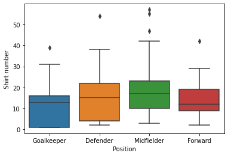

```python
sns.boxplot(x=LaLiga["Position"],y=LaLiga["Shirt number"])
```

#### - Los valores extremos, podemos comprobar que la posición en la que han jugado más jugadores provenientes de la segunda plantilla son mediocampistas, esto es debido en gran medida a 2 factores:

#### 1º) El mayor desgaste de los jugadores, ya que el centro del campo es la parcela en la que las disputas de balón son más frecuentes.

#### 2º) El fútbol de élte cada vez exige a sus futbolistas un conocimiento general mayor de todos los aspectos del juego. Para ello los jugadores que juegan en una zona intermedia por condición tienen menos complicado mecanixar todos los automatismos del juego.

```python
goles_cabeza = (LaLiga.groupby('Team').agg(suma_goles_cabeza = ('Goals scored with header','count')))
goles_cabeza
```

| Team | suma_goles_cabeza |
| --- | --- |
| Athletic Club | 29 |
| Atlético de Madrid | 32 |
| CD Leganés | 29 |
| D. Alavés | 26 |
| FC Barcelona | 26 |
| Getafe CF | 24 |
| Girona FC | 29 |
| Levante UD | 26 |
| R. Valladolid CF | 30 |
| RC Celta | 25 |
| RCD Espanyol | 28 |
| Rayo Vallecano | 33 |
| Real Betis | 30 |
| Real Madrid | 31 |
| Real Sociedad | 33 |
| SD Eibar | 23 |
| SD Huesca | 25 |
| Sevilla FC | 26 |
| Valencia CF | 24 |
| Villarreal CF | 27 |

### Equipos que participan en más duelos

```python
jugadores_mas_duelos = (LaLiga.groupby('Team').agg(suma_duelos_parejos =('Man-to-man duels','sum')))
jugadores_mas_duelos
```

| Team | suma_duelos_parejos |
| --- | --- |
| Athletic Club | 2958 |
| Atlético de Madrid | 2940 |
| CD Leganés | 2480 |
| D. Alavés | 2665 |
| FC Barcelona | 2822 |
| Getafe CF | 2713 |
| Girona FC | 2875 |
| Levante UD | 3009 |
| R. Valladolid CF | 2889 |
| RC Celta | 2719 |
| RCD Espanyol | 2803 |
| Rayo Vallecano | 3256 |
| Real Betis | 2815 |
| Real Madrid | 3036 |
| Real Sociedad | 3001 |
| SD Eibar | 2706 |
| SD Huesca | 2785 |
| Sevilla FC | 2807 |
| Valencia CF | 2863 |
| Villarreal CF | 2799 |

```python
posiciones_mas_duelos= (LaLiga.groupby('Position').agg(suma_de_duelos_disputados =('Man-to-man duels','sum')))
posiciones_mas_duelos
```

| Position | suma_de_duelos_disputados |
| --- | --- |
| Defender | 16229 |
| Forward | 12845 |
| Goalkeeper | 119 |
| Midfielder | 27748 |

#### Existe una clara diferencia entre los duelos entre centrocampistas en relación al resto, debido al motivo que se ha explicado anteriormente.

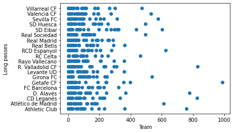

```python
plt.scatter(LaLiga["Long passes"],LaLiga["Team"])
plt.ylabel("Long passes")
plt.xlabel("Team")
plt.show()
```

### Aquí lo vemos representado en un gráfico

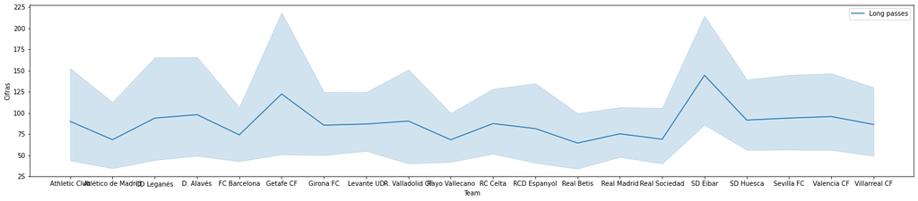

```python
fig, ax = plt.subplots(nrows = 1, figsize=(25, 5))

ax = sns.lineplot(x='Team',y='Long passes',data=LaLiga, label='Long passes')

ax.set(ylabel = 'Cifras')
ax.legend()
plt.show()
```

### Grafica de tarjetas amarillas

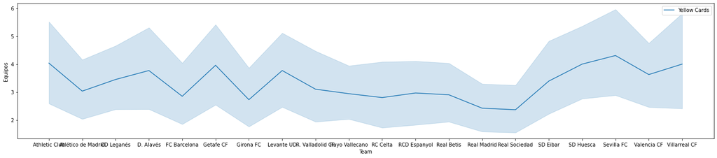

```python
fig, ax = plt.subplots(nrows = 1, figsize=(25, 5))

ax = sns.lineplot(x='Team',y='Yellow Cards',data=LaLiga, label='Yellow Cards')

ax.set(ylabel = 'Equipos')
ax.legend()
plt.show()
```

#### Juntando esta gráfica con la anterior se puede ver la existencia de correlación positiva entre las tarjetas amarillas y los pases largos. Esto es debido a que los equipos que realizan más pases largos tienden a dedicarse a defender(generalmente en bloque bajo) mucho más tiempo que a atacar en sus partidos. Por lo que es más probable que realicen más faltas ya que disponen de menos tiempo de posesión de balón.

### Grafica goles marcados-tarjetas amarillas-tarjetas rojas

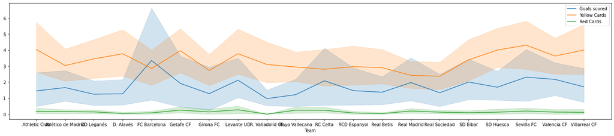

```python
fig, ax = plt.subplots(nrows = 1, figsize=(25, 5))

ax = sns.lineplot(x='Team',y='Goals scored',data=LaLiga, label='Goals scored')
ax = sns.lineplot(x='Team',y='Yellow Cards',data=LaLiga, label='Yellow Cards')
ax = sns.lineplot(x='Team',y='Red Cards',data=LaLiga, label='Red Cards')
ax.set(ylabel = '')
ax.legend()
plt.show()
```

#### Respecto a las tarjetas rojas no se puede apreciar del mismo modo la diferencia debido a que estas se dan en menor cantidad, sin embargo el hecho que comentamos respecto a las tarjetas amarillas se da en mayor en relación a las tarjetas rojas. El principal objetivo de esta gráfica además de mostrar los datos mencionados es mostrar un ejemplo de como se puede engañar mediante la visualización datos verídicos.

### Displot De goles anotados

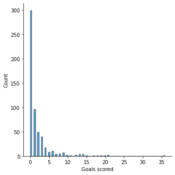

```python
sns.displot(LaLiga, x="Goals scored")
```

#### De forma clara se observa una correlación negativa. La mayoría de jugadores de hecho ni siquiera llegan a notar por lo que se percibe una gran concentración de los goles. Es digno de mención la diferencia abismal que se encuentra entre el primer jugador (Leo Messi) y la segunda posición, compartida por Luis Suárez y Karim Benzemá, ambos con 21 goles.

### Dispersión goles-partidos comenzados

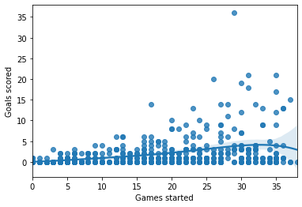

```python
sns.regplot(x='Games started',y='Goals scored',data=LaLiga,order=5)
plt.show()
```

#### Evidentemente al comenzar más partidos resulta más facil marcar más goles, sin embargo vemos que la linea de regresión tiene un ángula bastante bajo. Podemos contemplar en el valor más apartado los 36 goles de Leo messi disputando 29 partidos, o los 38 partidos de Diego López con 0 goles en contraposición.

### Gráfico de densidad de tarjetas amarillas

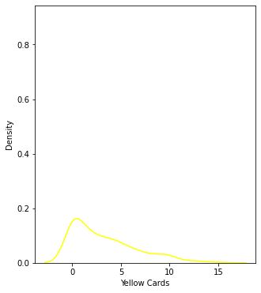

```python
plt.figure(figsize=(5, 6))
sns.distplot(LaLiga['Yellow Cards'], color='yellow', bins=50, hist_kws={'alpha': 0.005});
```

#### La gran mayoría de jugadores reciben claramente entre 0 y 5 tarjetas amarillas, el 100% de la distribución de jugadores se da en el punto 15 del eje x el cual supone el máximo número de tarjetas amarillas recibidas por un jugador.

### Gráfico de densidad de tarjetas rojas

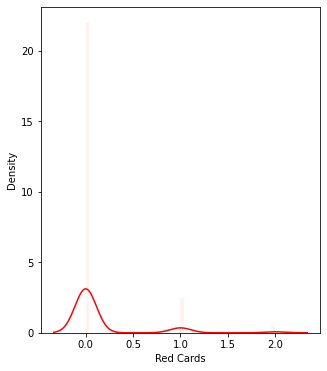

```python
plt.figure(figsize=(5, 6))
sns.distplot(LaLiga['Red Cards'], color='red', bins=50, hist_kws={'alpha': 0.05});
```

#### Podemos observar la misma tendencia que en la anterior gráfica pero con valores mucho más concentrados. La gran mayoría de jugadores no llegan a recibir 1 mientras que el número máximo de las mismas, es solo 2.

## Conclusiones

#### - En los equipos de la Liga existe una variedad de métodos de juego muy amplia.

#### - En los equipos de esta liga no hay una apuesta por la cantera marcada (en términos absolutos).

#### - Los equipos que tratan de jugar más con el balón reciben menos amonestaciones.

#### - La correlación positiva entre los partidos disputados y los goles anotados es clara, sin embargo las cifras de goles se encuentran bastante concentradas.

## Referencias

#### Apuntes varios de la asignatura de Programación en Python

#### https://www.kaggle.com/ekami66/detailed-exploratory-data-analysis-with-python

#### https://seaborn.pydata.org/tutorial/distributions.html